# C.E.A.P analysis (suppliers and weekend expenses)

Exploratory data analysis on ‘Quota for the exercise of parliamentary activity’ provided by the Brazilian government

José Benardi de Souza Nunes

06/09/2018

# Introduction

> This exploratory data analysis was made based on data provided by the Brazilian government about the expenses allowed to its parliamentarians or C.E.A.P. (Cota para o Exercício da Atividade Parlamentar / Quota for the Exercise of Parliamentary Activity). More information about it (in Portuguese) can be found in its [official site](http://www2.camara.leg.br/transparencia/acesso-a-informacao/copy_of_perguntas-frequentes/cota-para-o-exercicio-da-atividade-parlamentar)

# Data Overview

```r
data <- read_csv(here::here("data/dadosCEAP.csv"),
                 progress = F,
                 col_types = cols(
                   nomeParlamentar = col_character(),
                   idCadastro = col_integer(),
                   sgUF = col_character(),
                   sgPartido = col_character(),
                   tipoDespesa = col_character(),
                   especDespesa = col_character(),
                   fornecedor = col_character(),
                   CNPJCPF = col_character(),
                   tipoDocumento = col_integer(),
                   dataEmissao = col_character(),
                   valorDocumento = col_double(),
                   valorGlosa = col_integer(),
                   valorLíquido = col_double()))

data %>%
  mutate(dataEmissao = parse_date_time(dataEmissao,"%Y-%m-%d %H:%M:%S"),
         year_month = paste(lubridate::year(dataEmissao),   # extract year
                            lubridate::month(dataEmissao),  # extract month
                            sep = "-"),
         tipoDespesa = toupper(tipoDespesa)) -> data

state_info <- read_csv(here::here("/data/limiteMensalCEAP.csv"),
                       progress = F,
                       col_types = cols(
                         UF = col_character(),
                         limite_mensal = col_double()))

data %>%
  full_join(state_info,
            by = c("sgUF" = "UF")) -> data

data %>%
  glimpse()
```

```
## Observations: 963,452
## Variables: 15
## $ nomeParlamentar <chr> "ABEL MESQUITA JR.", "ABEL MESQUITA JR.", "ABE...
## $ idCadastro      <int> 178957, 178957, 178957, 178957, 178957, 178957...
## $ sgUF            <chr> "RR", "RR", "RR", "RR", "RR", "RR", "RR", "RR"...
## $ sgPartido       <chr> "DEM", "DEM", "DEM", "DEM", "DEM", "DEM", "DEM...
## $ tipoDespesa     <chr> "MANUTENÇÃO DE ESCRITÓRIO DE APOIO À ATIVIDADE...
## $ especDespesa    <chr> NA, NA, NA, NA, NA, "Veículos Automotores", "V...
## $ fornecedor      <chr> "COMPANHIA DE AGUAS E ESGOTOS DE RORAIMA", "CO...
## $ CNPJCPF         <chr> "05939467000115", "05939467000115", "023414700...
## $ tipoDocumento   <int> 0, 0, 0, 0, 0, 0, 0, 0, 0, 0, 0, 0, 0, 0, 0, 0...
## $ dataEmissao     <dttm> 2015-11-14, 2015-12-10, 2015-11-27, 2015-12-3...
## $ valorDocumento  <dbl> 165.65, 59.48, 130.95, 196.53, 310.25, 32.00, ...
## $ valorGlosa      <int> 0, 0, 0, 347, 0, 0, 0, 0, 0, 0, 0, 0, 0, 0, 0,...
## $ valorLíquido    <dbl> 165.65, 59.48, 130.95, 193.06, 310.25, 32.00, ...
## $ year_month      <chr> "2015-11", "2015-12", "2015-11", "2015-12", "2...
## $ limite_mensal   <dbl> 45612.53, 45612.53, 45612.53, 45612.53, 45612....
```

```r
read_tsv(here::here("data/trsl_expenses.tsv"),
         progress = F,
         col_types = cols(
           original_term = col_character(),
           translation = col_character())) -> trsltd_expenses

trsltd_expenses
```

| original_term | translation |
| --- | --- |
| MANUTENÇÃO DE ESCRITÓRIO DE APOIO À ATIVIDADE PARLAMENTAR | MAINTENANCE OF OFFICE TO SUPPORT PARLIAMENTARY ACTIVITY |
| COMBUSTÍVEIS E LUBRIFICANTES. | FUELS AND LUBRICANTS. |
| CONSULTORIAS, PESQUISAS E TRABALHOS TÉCNICOS. | CONSULTANCIES, RESEARCH AND TECHNICAL WORKS. |
| DIVULGAÇÃO DA ATIVIDADE PARLAMENTAR. | DIVULGATION OF PARLIAMENTARY ACTIVITY. |
| SERVIÇO DE SEGURANÇA PRESTADO POR EMPRESA ESPECIALIZADA. | SECURITY SERVICE PROVIDED BY SPECIALIZED COMPANY. |
| PASSAGENS AÉREAS | AIRLINE TICKETS |
| SERVIÇOS POSTAIS | POSTAL SERVICES |
| FORNECIMENTO DE ALIMENTAÇÃO DO PARLAMENTAR | SUPPLY OF FOOD FOR PARLIAMENTARIAN |
| TELEFONIA | TELEPHONY |
| LOCAÇÃO OU FRETAMENTO DE VEÍCULOS AUTOMOTORES | LEASING OR FREIGHTING OF AUTOMOTIVE VEHICLES |

[output cut: 8 more lines]

- A translation for the description of each one of the 18 types of expense was recorded alongside its original term.

```r
data %>%
  full_join(trsltd_expenses,
            by = c("tipoDespesa" = "original_term"))  %>%
  mutate(tipoDespesa = translation) %>%  # translate col tipoDespesa
  select(-translation)-> data # drop unused column

data %>%
  sample_n(5) %>%
  select(nomeParlamentar,
         tipoDespesa,
         dataEmissao)
```

| nomeParlamentar | tipoDespesa | dataEmissao |
| --- | --- | --- |
| HUGO LEAL | AIR TICKET ISSUANCE | 2017-01-23 |
| VINICIUS CARVALHO | FUELS AND LUBRICANTS. | 2015-09-18 |
| ROBERTO BRITTO | SUPPLY OF FOOD FOR PARLIAMENTARIAN | 2016-06-02 |
| GOULART | AIR TICKET ISSUANCE | 2016-05-30 |
| HENRIQUE FONTANA | AIR TICKET ISSUANCE | 2016-06-15 |

- We now have each term in the column tipoDespesa translated.

```r
data %>%
  mutate(week_day = wday(dataEmissao), # extract week day
         is_weekend = (week_day == 1) |  # deduce whether it's a weekend
                         (week_day == 7)) -> data

data %>%
  select(dataEmissao,
         week_day,
         is_weekend) %>%
  sample_n(5)
```

| dataEmissao | week_day | is_weekend |
| --- | --- | --- |
| 2015-06-23 | 3 | FALSE |
| 2015-06-01 | 2 | FALSE |
| 2016-11-11 | 6 | FALSE |
| 2016-03-18 | 6 | FALSE |
| 2015-04-17 | 6 | FALSE |

- Once we extracted which day of the week the emission was made we simply deduced whether it was a weekend or not.

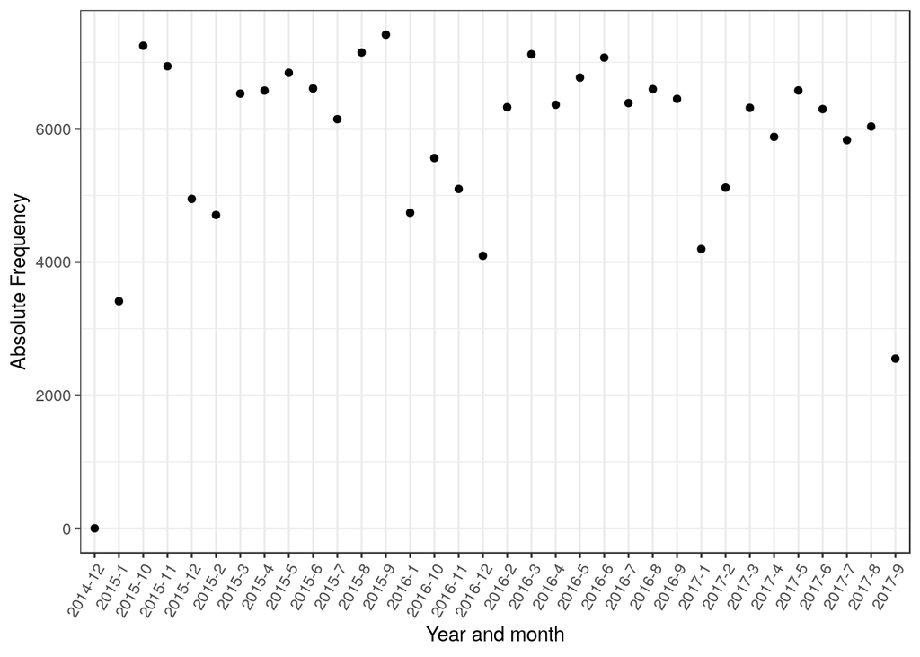

```r
data %>%
  na.omit(year_month) %>%
  group_by(year_month) %>%     # times used
  summarize(total = n()) %>%   # by year/month
  ggplot(aes(year_month, total)) +
  geom_point() +
  theme(axis.text.x = element_text(angle = 60,
                                   hjust = 1)) +
  labs(x="Year and month", y="Absolute Frequency")
```

- The period of time covered by the dataset is of about 3 years which amounts to the duration of our parliamentarian’s office minus the 120 days prior to the election.

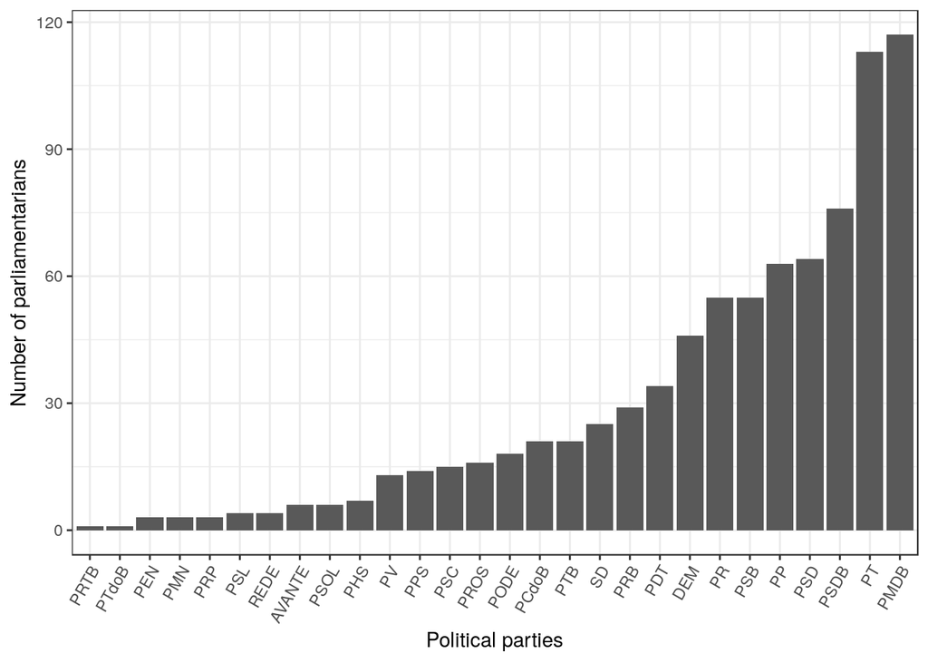

```r
data %>%
  group_by(idCadastro,
           nomeParlamentar) %>%
  slice(1) %>% # keep one entry for parliamentarian
  ungroup() %>%
  group_by(sgPartido) %>%              # calc parliamentarian
  summarize(num_parliament = n()) %>%  # by party
  na.omit() %>%
  ggplot(aes(reorder(sgPartido,
                     num_parliament),
             num_parliament)) +
  geom_bar(stat="identity") +
  labs(x="Political parties",
       y="Number of parliamentarians") +
  theme(axis.text.x = element_text(angle = 60,
                                   hjust = 1))
```

- We can see that **PMDB** detains the majority of offices followed closely by **PT** and that **PSDB** is still a major player. This was to be expected as the aforementioned parties are often regarded as the most prominent ones in the Brazilian political scene.

# Expenditure during the week and the weekends

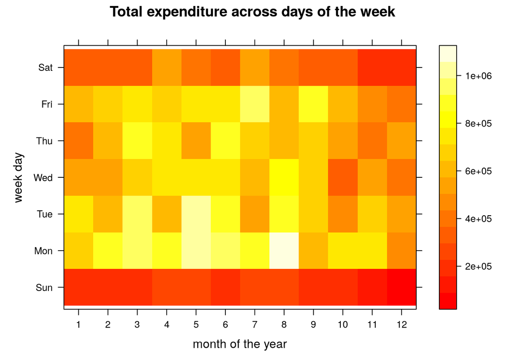

```r
data %>%
   mutate(month = lubridate::month(dataEmissao)) %>%  # extract month
  na.omit(week_day,month) %>%
  group_by(week_day,month) %>% # times used
  summarize(total = sum(valorLíquido)) %>%  # by day of week / month
  tidyr::spread(key= week_day, value=total,
                fill = 0) %>%
  select(-month) %>% data.matrix() -> matrix_yearly

colnames(matrix_yearly) <- c("Sun","Mon","Tue","Wed","Thu","Fri","Sat")

x.scale <- list(at=seq(from=1,to=12,by=1))

levelplot(matrix_yearly,
          col.regions=heat.colors,
          scales=list(x=x.scale),
          main="Total expenditure across days of the week",
          xlab="month of the year", ylab= "week day")
```

- Overall we can see a clear predominance of expenditures during the week as both **saturday** and **sunday** have a smaller total expenditure across the whole year.
  - It was to be expected, as CEAP is meant to be used to pay for work related expenses.

```r
data %>%
  group_by(is_weekend,sgPartido) %>%
  summarize(total_cost = sum(valorLíquido)) %>%
  na.omit(is_weekend) -> party_expense

party_expense %>%
  ungroup() %>%
  sample_n(5)
```

| is_weekend | sgPartido | total_cost |
| --- | --- | --- |
| TRUE | AVANTE | 256246.5 |
| TRUE | SD | 923473.7 |
| TRUE | PSD | 2275615.2 |
| FALSE | PTdoB | 13130.8 |
| FALSE | PSD | 39034324.5 |

- Now we have the total cost incurred by each party during the week and during the weekend.

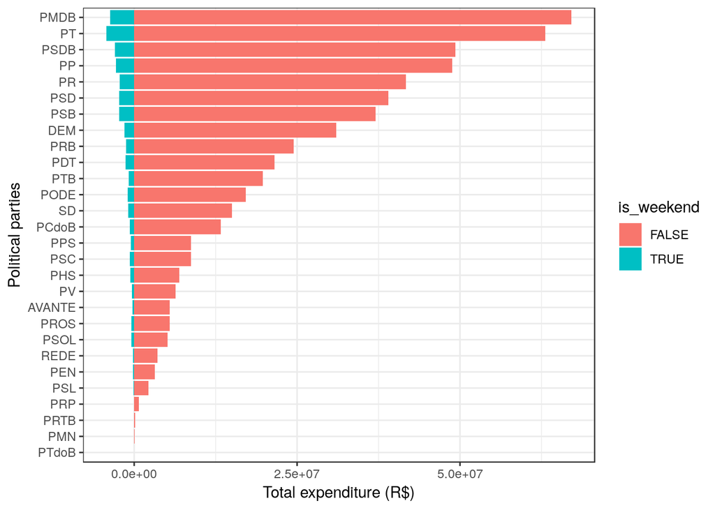

```r
ggplot(data= party_expense,
       aes(reorder(sgPartido,
                     total_cost),
             total_cost,
             fill=is_weekend)) +
  geom_bar(data=subset(party_expense,
                       !is_weekend),
           stat = "identity") +
  geom_bar(data=subset(party_expense,
                       is_weekend),
           aes(y=-total_cost),
           stat = "identity") +
  coord_flip() +
   labs(x="Political parties",
        y="Total expenditure (R$)")
```

- Across different political parties the strong predominance of expenditures during the week holds.
  - PMDB is the biggest spender.
- **PMDB**, **PT** and **PSDB** are the parties with the highest number of offices, therefore it’s reasonable that they are the ones to spend the most.

## Which parties spent the most during the weekend?

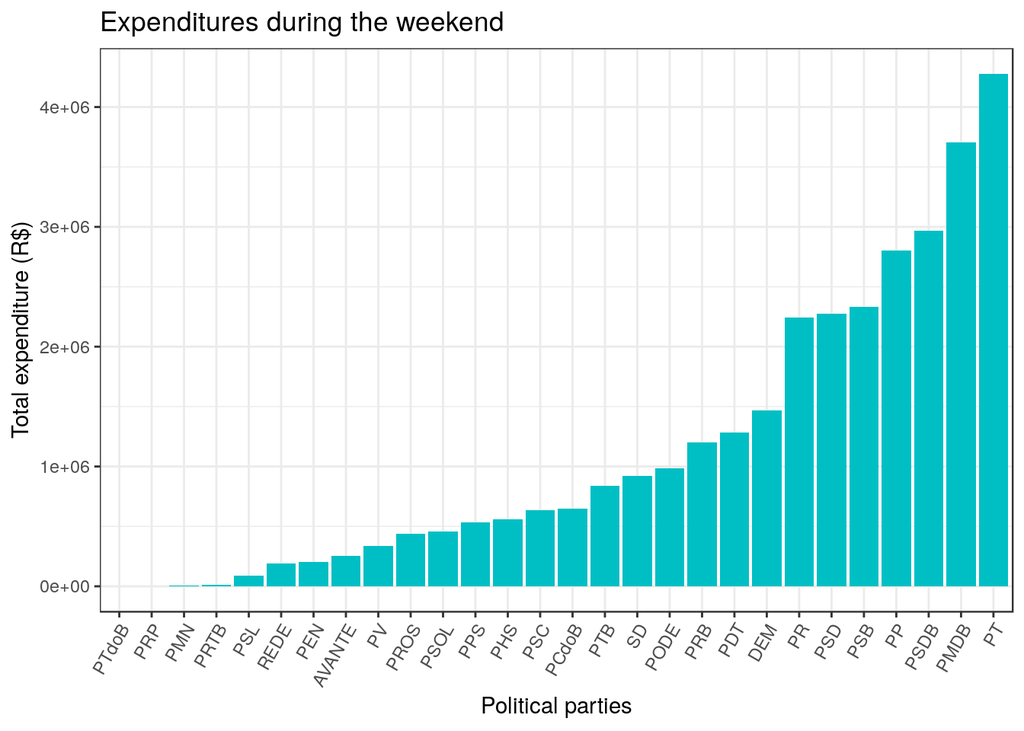

```r
data %>%
  filter(is_weekend) %>%
  group_by(is_weekend,sgPartido) %>%
  summarize(total_cost = sum(valorLíquido)) %>%
  na.omit(is_weekend) %>%
  ggplot(aes(reorder(sgPartido,
                     total_cost),
             total_cost)) +
  geom_bar(stat="identity",
           fill="#00BFC4") +
  labs(x="Political parties",
       y="Total expenditure (R$)",
       title="Expenditures during the weekend") +
  theme(axis.text.x = element_text(angle = 60,
                                   hjust = 1))
```

- **PMDB**, **PT** and **PSDB** are also the ones to spend the highest amount of money during the weekend.
- Despite the fact that overall **PMDB** is the biggest spender (as seen before) **PT** spent the most during the weekend.

> **PMDB**, **PT** and **PSDB** spent the most during the weekend.

## Which parties had most of their expenditures made during the weekend?

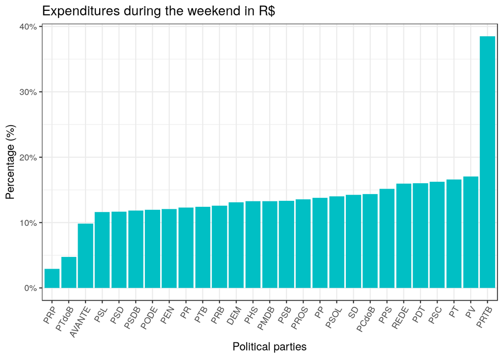

```r
data %>%
  na.omit(is_weekend,
          sgPartido) %>%
  group_by(sgPartido) %>%
  mutate(total = sum(valorLíquido)) %>% # calc total cost by party
  ungroup() %>%
  group_by(total,
           sgPartido,
           is_weekend) %>%                        # calc cost by weekdays
  summarize(total_cost = sum(valorLíquido)) %>%   # and by weekends
  mutate(fract = total_cost/total) %>%          # calc fraction
  filter(is_weekend) %>%
  ggplot(aes(reorder(sgPartido,fract),
             fract)) +
  geom_bar(stat="identity",
           fill="#00BFC4") +
    labs(x="Political parties",
       y="Percentage (%)",
       title="Expenditures during the weekend in R$") +
  scale_y_continuous(labels = scales::percent) +
  theme(axis.text.x = element_text(angle = 60,
                                   hjust = 1))
```

- Unexpectedly, we see as leader the party **PRTB** (ironically named Brazilian Labour Renewal Party) that made almost $40\%$ of its expenditures during the weekend.
- **PT** not only spent a great amount of money during the weekend as seen before, but had a substantial fraction of its expenditures made during the weekend.
- We can see that parties like **PV** and **PSC** which were obscured in terms of overall expense, stand out as some of the parties who spent a good part of their budget during the weekend.

> **PRTB** was the party to have most of its expenditures made during the weekend.

# Looking at the cost of the suppliers

## What were the costliest suppliers (in terms of median)? What services did they offer?

##### Let’s separate the top 10 most expensive suppliers. They will be selected by their median cost across all parties.

```r
data %>%
  mutate(fornecedor = toupper(fornecedor)) %>%
  mutate(fornecedor = ifelse(         # shorten the name
    fornecedor == "TODDE ADVOGADOS E CONSULTORES ASSOCIADOS",
    "TODDE ADVOGADOS",
    fornecedor)) %>%
  group_by(fornecedor,
           sgPartido,
           tipoDespesa) %>%              # calc expense of each
  summarize(total_cost = sum(valorLíquido)) %>% # supplier for each party
  ungroup() %>%
  group_by(fornecedor) %>%                           # calc median expense of
  mutate(median_expense = median(total_cost)) %>% # each supplier (all parties)
  ungroup() -> supplier_data

supplier_data %>%
  select(fornecedor,
         median_expense,
         sgPartido,
         total_cost) %>%
  sample_n(5)
```

| fornecedor | median_expense | sgPartido | total_cost |
| --- | --- | --- | --- |
| POSTO SAMUCA CUIABÁ LTDA. | 30.000 | PT | 30.00 |
| ESTACIONAMENTO O BECO LTDA | 163.000 | PSDB | 163.00 |
| XAXIM COM. DE COMBUSTIVEIS LTDA. | 92.500 | PSC | 162.00 |
| CMI AGÊNCIA DE MÍDIAS SOCIAIS E MARKETING DIGITAL LTDA | 197150.000 | PMDB | 197150.00 |
| VIAÇÃO AGUIA BRANCA | 998.395 | PT | 4308.85 |

- Now that we have the median cost of each supplier we can examine how the top 10 most expensive suppliers relate to the parties.

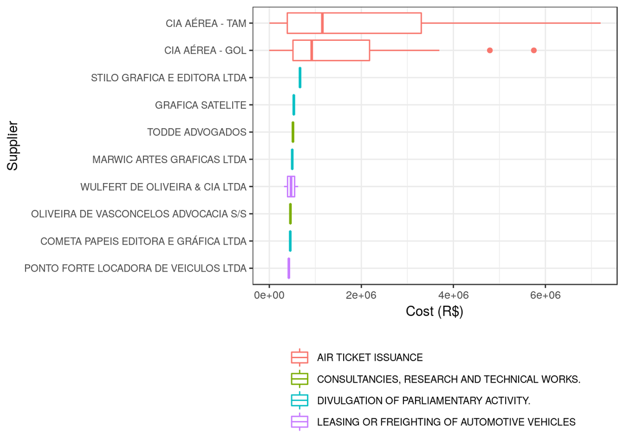

```r
supplier_data %>%
  select(median_expense) %>%
  unique() %>%
  arrange(desc(median_expense)) %>%
  slice(10) -> tenth_supplier # 10th biggest median cost

supplier_data %>%
  group_by(fornecedor,
           sgPartido,
           tipoDespesa) %>%
  filter(median_expense >= tenth_supplier) %>%  # filter top 10 suppliers
  ggplot(aes(reorder(fornecedor,
                     median_expense),
             total_cost,
             color=tipoDespesa)) +
  geom_boxplot() +
  labs(x="Supplier",
       y="Cost (R$)",
       color=NULL) +
  coord_flip()+
  theme(legend.position="bottom",
        legend.direction = "vertical") +
    theme(legend.text=element_text(size=8),
           axis.text.y = element_text(size=8))
```

- TAM and GOL which are both air flight companies have the most diverse behavior, accounting for the lowest cost in the top 10 but majoritarily being *the costliest suppliers of all*.
  - In terms of median the air flight companies **TAM** and **GOL** take first and second place as costliest suppliers of all with $\color{red}{\text{Air Ticket Issuance}}$
- The rest of the suppliers are plainly less erratic.
  - Publicity and advertising companies such as **STILO GRAFICA** and **GRAFICA SATELITE** take the third and fourth place with $\color{blue}{\text{Divulgation of parliamentary activity}}$.
  - The law firm **Todde advogados e consultores associados** takes the fifth place with $\color{darkgreen}{\text{Consultancies, research and technical works}}$

> The costliest suppliers of all were **TAM** and **GOL** with *Air Ticket Issuance*